# TWFE・ETWFEによる退出と出資比率の推定

# 6 感度分析

- Using the method proposed by [Rambachan and Roth (2022)](https://jonathandroth.github.io/assets/files/HonestParallelTrends_Main.pdf), we conduct a sensitivity analysis to assess the robustness of the results to potential violations of the parallel trends assumption. The method is implemented in the `HonestDiD` package in R.

```
remotes::install_github("asheshrambachan/HonestDiD")
```

## 6.1 Store the TWFE results

```r
betahat <- summary(es6)$coefficients
sigma <-   summary(es6)$cov.scaled

# CI
library(HonestDiD)
originalResults <- HonestDiD::constructOriginalCS(
  betahat = betahat, # TWFE
  sigma = sigma, # TWFE
  l_vec = basisVector(index = 5, size = 5),
  numPrePeriods = 2, # pre-periods
  numPostPeriods = 5 # post-periods
)
```

## 6.2 Relative magnitudes restriction

```r
library(HonestDiD)

# Relative magnitudes
delta_rm_results <-
  HonestDiD::createSensitivityResults_relativeMagnitudes(
    betahat = betahat, # TWFE
    sigma = sigma, # TWFE
    numPrePeriods = 2, # Pre-period
    numPostPeriods = 5, # Post-period
    Mbarvec = seq(0.5, 2, by = 0.5), # Mbar
    l_vec = basisVector(index = 5, size = 5) # post 5
  )

delta_rm_results
```

```
## # A tibble: 4 x 5
##        lb     ub method Delta    Mbar
##     <dbl>  <dbl> <chr>  <chr>   <dbl>
## 1 -0.0965 0.0517 C-LF   DeltaRM   0.5
## 2 -0.160  0.116  C-LF   DeltaRM   1
## 3 -0.226  0.182  C-LF   DeltaRM   1.5
## 4 -0.293  0.249  C-LF   DeltaRM   2
```

## 6.3 Plot

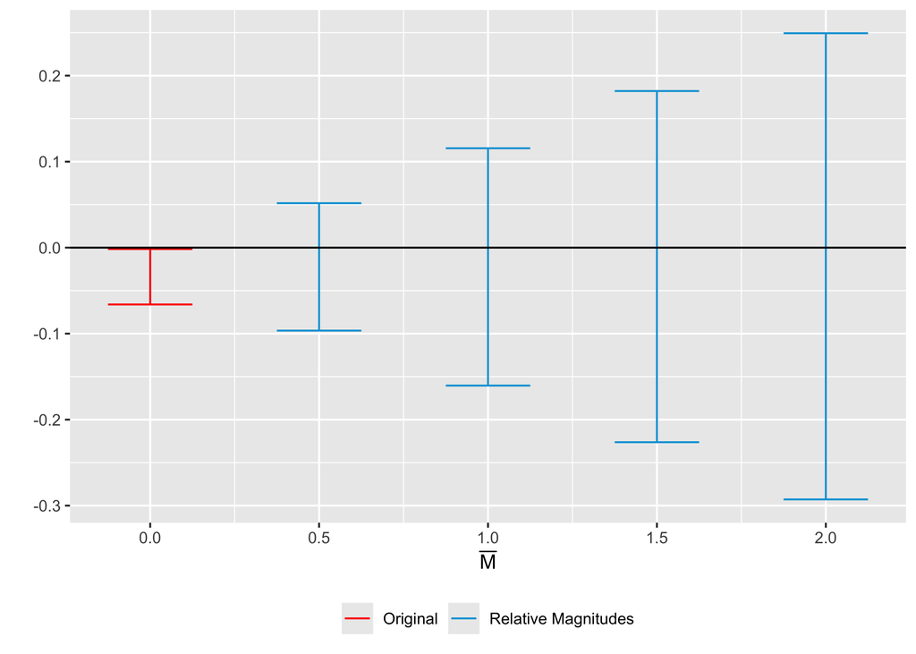

```r
# Rename labels
delta_rm_results$method <- "Relative Magnitudes"

# sensitivity plot
s1 <- HonestDiD::createSensitivityPlot_relativeMagnitudes(delta_rm_results, originalResults)

s1
```

## 6.4 Smoothness bound

```r
# smoothness bound
# HonestDiD のバージョンによっては、既定の FLCI 計算が失敗することがある。
# その場合は Conditional に切り替えて、感度分析を継続する。
delta_sd_results <- tryCatch(
  HonestDiD::createSensitivityResults(
    betahat = betahat, # TWFE
    sigma = sigma, # TWFE
    numPrePeriods = 2, # pre-periods
    numPostPeriods = 5, # post-periods
    Mvec = seq(0.005, 0.010, by = 0.005), # M
    l_vec = basisVector(index = 5, size = 5), # post 5
    method = "FLCI"
  ),
  error = function(e) {
    message("FLCI が失敗したため、Conditional に切り替えます。")
    HonestDiD::createSensitivityResults(
      betahat = betahat,
      sigma = sigma,
      numPrePeriods = 2,
      numPostPeriods = 5,
      Mvec = seq(0.005, 0.010, by = 0.005),
      l_vec = basisVector(index = 5, size = 5),
      method = "Conditional"
    )
  }
)
```

```r
# Rename labels
delta_sd_results$method <- "Smoothness bound"
delta_sd_results
```

```
## # A tibble: 2 x 5
##       lb    ub method           Delta       M
##    <dbl> <dbl> <chr>            <chr>   <dbl>
## 1 -0.240 0.111 Smoothness bound DeltaSD 0.005
## 2 -0.310 0.182 Smoothness bound DeltaSD 0.01
```

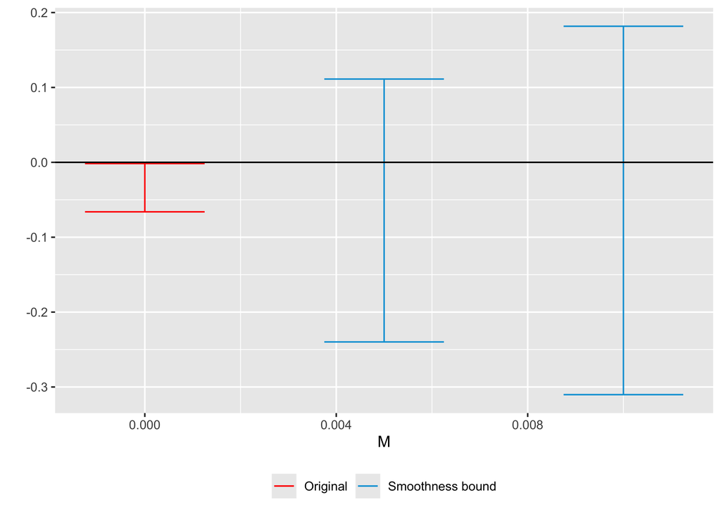

```r
# Plot
s2 <- HonestDiD::createSensitivityPlot(delta_sd_results, originalResults)

s2
```

## 6.5 Combine s1 and s2 graph

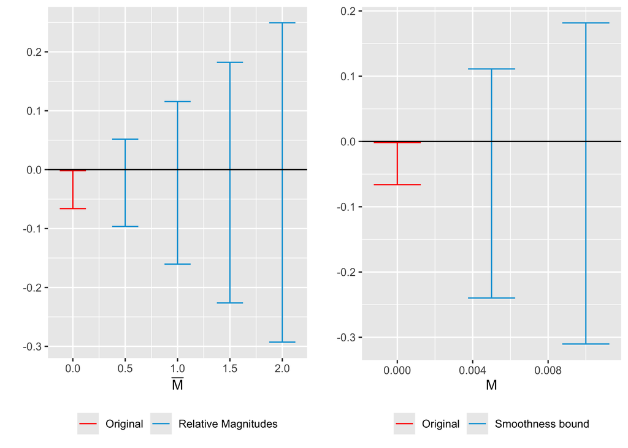

```r
# Combine the two plots
gridExtra::grid.arrange(s1, s2, ncol = 2)
```

# References

- [Create a publication-ready LaTeX regression table with `kableExtra` in R](https://tilburgsciencehub.com/topics/visualization/reporting-tables/reportingtables/kableextra/)
- [modelsummary: regression tables](https://modelsummary.com/articles/modelsummary.html)
- `fixest`
  - [fixest: Exporting estimation tables](https://lrberge.github.io/fixest/articles/exporting_tables.html#exporting-multiple-estimations-to-latex)
  - [Fast Fixed-Effects Estimation: Short Introduction](https://cran.r-project.org/web/packages/fixest/vignettes/fixest_walkthrough.html)
- For OLS:
  - [Fixed-effects OLS estimations](https://lrberge.github.io/fixest/reference/feols.html)
- For Logit model:
  - [Fixed-effects GLM estimations](https://lrberge.github.io/fixest/reference/feglm.html)
  - [family: Family Objects for Models](https://rdrr.io/r/stats/family.html)
  - [LOGIT REGRESSION | R DATA ANALYSIS EXAMPLES](https://stats.oarc.ucla.edu/r/dae/logit-regression/)
- HonestDiD